# mashable_master_2017.09.17.22.35_n_minus_1

#### Keywords and Mashable-refernced hyperlinks

The data set contains an interesting feature idea for this evaluation. The links that are embedded in each article, prior to publication, are evaluated for the keywords in those links and the number of social media shares associated to those embedded links. These are then scored relative to the success rates of the each of the keywords on a best/avg/worst basis. This is an interesting concept, in essence, to use previous related social media share success / failure keywords as an estimator of a to-be-published article. Since this is an interesting, and potentially useful, feature in this data set, we decided to explore with a simple data view to visualize the relationship between _keywords_avg*max* and _self_reference*shares*, to verify that the distributions are understood and also that there is non-dependency between features such as _kw_avg*max* and _self_reference*shares*.  
From this, we observe the following :

- The histograms shows a reasonably sized portion of each population distributed along the full domain range of each feature. This is a positive characteristic of the data set for future analysis.
- The scatter plots shows that there is little correlation between the two features, again identifying that these features are likely sufficiently non-correlated as to be useful in model building.

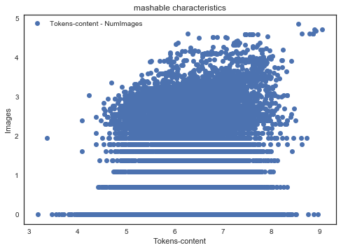

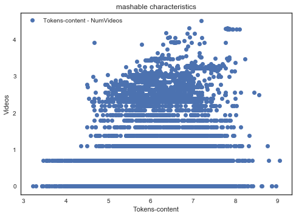

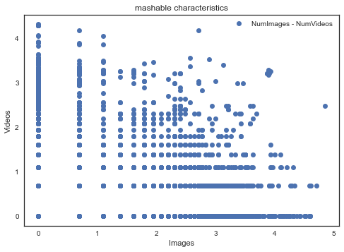

```python
# ... -=-=-=-=-=-=-=-=-=-=-=-=-=-=-=-=-=-=-=-=-=-=-=-=-=-=-=-=-=-=-=-=-=-=-=-=-=
# ... Tokens, Images, Videos plots
# ... -=-=-=-=-=-=-=-=-=-=-=-=-=-=-=-=-=-=-=-=-=-=-=-=-=-=-=-=-=-=-=-=-=-=-=-=-=
import numpy as np

df1.log_n_tokens = np.log(df1['n_tokens_content'])
df1.log_n_imgs = np.log(df1['num_imgs'])
df1.log_n_videos = np.log(df1['num_videos'])

plt.plot(df1.log_n_tokens, df1.log_n_imgs, label = 'Tokens-content - NumImages', linestyle = 'None', marker = 'o')
plt.xlabel('Tokens-content')
plt.ylabel('Images')
plt.title('mashable characteristics')
plt.legend()
plt.show()

plt.plot(df1.log_n_tokens, df1.log_n_videos, label = 'Tokens-content - NumVideos', linestyle = 'None', marker = 'o')
plt.xlabel('Tokens-content')
plt.ylabel('Videos')
plt.title('mashable characteristics')
plt.legend()
plt.show()

plt.plot(df1.log_n_imgs, df1.log_n_videos, label = 'NumImages - NumVideos', linestyle = 'None', marker = 'o')
plt.xlabel('Images')
plt.ylabel('Videos')
plt.title('mashable characteristics')
plt.legend()
plt.show()
```

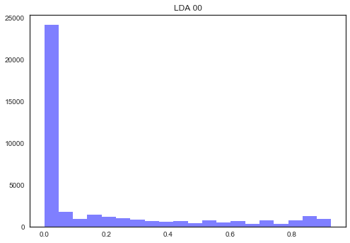

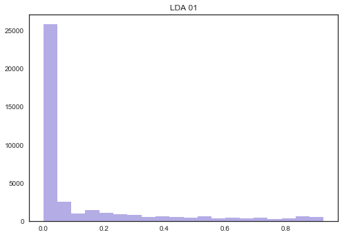

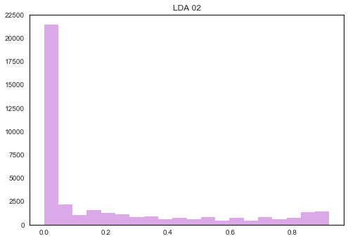

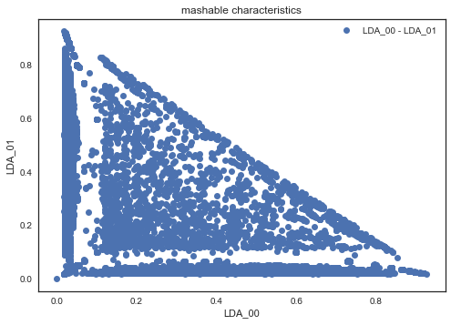

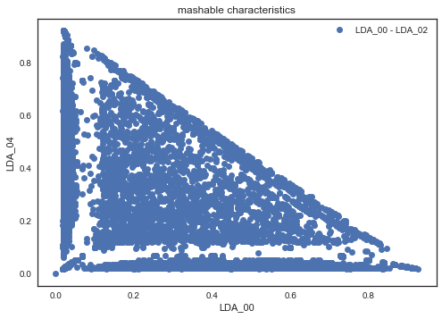

```python
# ... -=-=-=-=-=-=-=-=-=-=-=-=-=-=-=-=-=-=-=-=-=-=-=-=-=-=-=-=-=-=-=-=-=-=-=-=-=
# ... LDA plots
# ... -=-=-=-=-=-=-=-=-=-=-=-=-=-=-=-=-=-=-=-=-=-=-=-=-=-=-=-=-=-=-=-=-=-=-=-=-=

num_bins = 20
plt.hist(df1.LDA_00, num_bins, facecolor='blue', alpha=0.5)
plt.title('LDA 00')
plt.show()

num_bins = 20
plt.hist(df1.LDA_01, num_bins, facecolor='slateblue', alpha=0.5)
plt.title('LDA 01')
plt.show()

num_bins = 20
plt.hist(df1.LDA_02, num_bins, facecolor='mediumorchid', alpha=0.5)
plt.title('LDA 02')
plt.show()

plt.plot(df1.LDA_00, df1.LDA_01, label = 'LDA_00 - LDA_01', linestyle = 'None', marker = 'o')
plt.xlabel('LDA_00')
plt.ylabel('LDA_01')
plt.title('mashable characteristics')
plt.legend()
plt.show()

plt.plot(df1.LDA_00, df1.LDA_02, label = 'LDA_00 - LDA_02', linestyle = 'None', marker = 'o')
plt.xlabel('LDA_00')
plt.ylabel('LDA_04')
plt.title('mashable characteristics')
plt.legend()
plt.show()
```

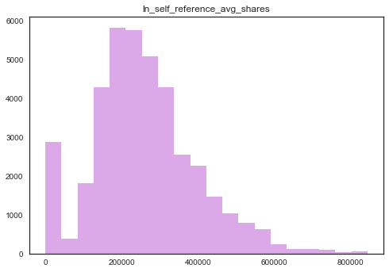

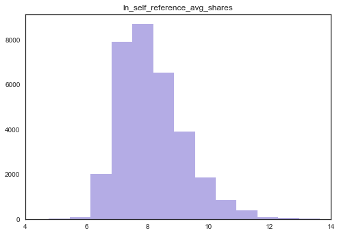

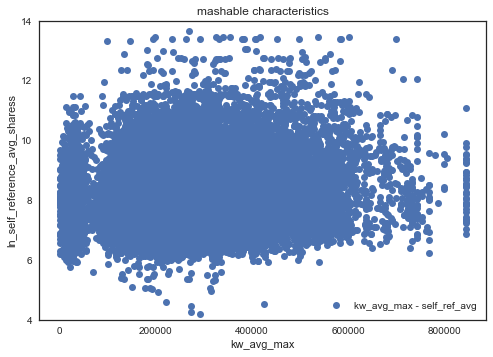

```python
# ... -=-=-=-=-=-=-=-=-=-=-=-=-=-=-=-=-=-=-=-=-=-=-=-=-=-=-=-=-=-=-=-=-=-=-=-=-=
# ... Keywords visualizations
# ... -=-=-=-=-=-=-=-=-=-=-=-=-=-=-=-=-=-=-=-=-=-=-=-=-=-=-=-=-=-=-=-=-=-=-=-=-=
import numpy as np

num_bins = 20
plt.hist(df1.kw_avg_max, num_bins, facecolor='mediumorchid', alpha=0.5)
plt.title('ln_self_reference_avg_shares')
plt.show()

df1.log_self_share = np.log(df1['self_reference_avg_sharess'] + 1)
axes = plt.gca()
axes.set_xlim([4,14])
num_bins = 20
plt.hist(df1.log_self_share, num_bins, facecolor='slateblue', alpha=0.5)
plt.title('ln_self_reference_avg_shares')
plt.show()

axes = plt.gca()
axes.set_ylim([4,14])
plt.plot(df1.kw_avg_max, df1.log_self_share, label = 'kw_avg_max - self_ref_avg', linestyle = 'None', marker = 'o')
plt.xlabel('kw_avg_max')
plt.ylabel('ln_self_reference_avg_sharess')
plt.title('mashable characteristics')
plt.legend()
plt.show()
```

### Explore Attributes and Class

#### Identify and explain interesting relationships between features and dependent variable popularity.

- In this case, the dependent variable, *popularity*, is a binary value : Yes or No

```python
import matplotlib.pyplot as plt
import pandas as pd
import seaborn as sb
import numpy as np
```

```python
dataset = df1

dataset.info()
```

```
<class 'pandas.core.frame.DataFrame'>
RangeIndex: 39644 entries, 0 to 39643
Data columns (total 75 columns):
url                              39644 non-null object
timedelta                        39644 non-null int64
n_tokens_title                   39644 non-null int64
n_tokens_content                 39644 non-null int64
n_unique_tokens                  39644 non-null float64
n_non_stop_words                 39644 non-null float64
n_non_stop_unique_tokens         39644 non-null float64
num_hrefs                        39644 non-null int64
num_self_hrefs                   39644 non-null int64
num_imgs                         39644 non-null int64
num_videos                       39644 non-null int64
average_token_length             39644 non-null float64
num_keywords                     39644 non-null int64
data_channel_is_lifestyle        39644 non-null float64
data_channel_is_entertainment    39644 non-null float64
data_channel_is_bus              39644 non-null float64
data_channel_is_socmed           39644 non-null float64
data_channel_is_tech             39644 non-null float64
data_channel_is_world            39644 non-null float64
kw_min_min                       39644 non-null float64
kw_max_min                       39644 non-null float64
kw_avg_min                       39644 non-null float64
kw_min_max                       39644 non-null float64
kw_max_max                       39644 non-null float64
kw_avg_max                       39644 non-null float64
kw_min_avg                       39644 non-null float64
kw_max_avg                       39644 non-null float64
kw_avg_avg                       39644 non-null float64
self_reference_min_shares        39644 non-null float64
self_reference_max_shares        39644 non-null float64
self_reference_avg_sharess       39644 non-null float64
weekday_is_monday                39644 non-null float64
weekday_is_tuesday               39644 non-null float64
weekday_is_wednesday             39644 non-null float64
weekday_is_thursday              39644 non-null float64
weekday_is_friday                39644 non-null float64
weekday_is_saturday              39644 non-null float64
```

[output cut: 25 more lines]

```
month                            39644 non-null object
day                              39644 non-null object
title                            39644 non-null object
publish_date                     39644 non-null datetime64[ns]
day_of_week                      39644 non-null object
data_channel                     33510 non-null object
popularity                       39644 non-null bool
ln_n_tokens_content              39644 non-null float64
ln_num_hrefs                     39644 non-null float64
ln_num_imgs                      39644 non-null float64
ln_num_videos                    39644 non-null float64
ln_kw_avg_avg                    39644 non-null float64
ln_self_reference_avg_sharess    39644 non-null float64
dtypes: bool(1), datetime64[ns](1), float64(57), int64(9), object(7)
memory usage: 22.4+ MB
```

#### Popularity by data channel

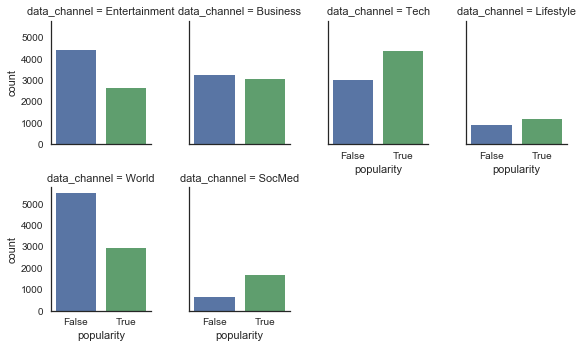

```python
sb.factorplot("popularity", col="data_channel", col_wrap=4,data=dataset,kind="count", size=2.5, aspect=.8)
plt.show()
```

#### Number of videos in content

- Does number of videos matter ?
- Social media distributions show a positive correlation with number of videos
- The remainder of the data channels do not show an appreciable difference in True/False (Yes/No) responses to the number of videos.
- In this case, we present the num_videos values on ln(num_videos) scale, due to the very wide range of number of videos in the experience set, and also, the generally highly right-skewed characteristics of those distributions.

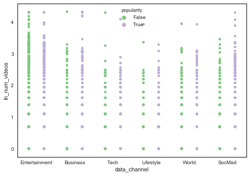

```python
sb.stripplot(x='data_channel',y='ln_num_videos',data=dataset,hue='popularity', split=True,palette="Accent");
plt.show()
```

#### online behaviour on mashable by day of week

- Does day of week that the article was published have an influence on the eventual number of shares for that article ?

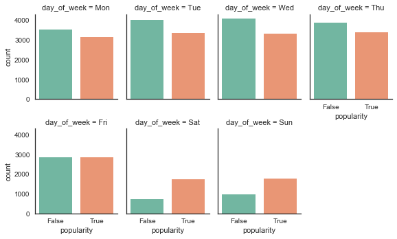

```python
sb.factorplot("popularity", col="day_of_week", col_wrap=4,data=dataset,kind="count", size=2.5, aspect=.8,palette="Set2")
plt.show()
```

#### Does having images have an impact on popularity?

- Lets plot it out!

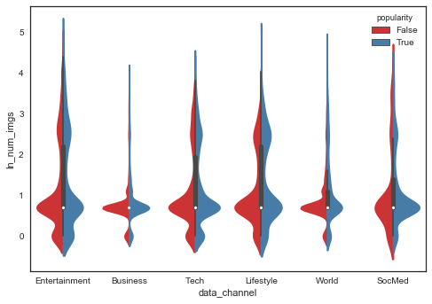

```python
sb.violinplot(x='data_channel',y='ln_num_imgs',data=dataset,hue='popularity', split=True,palette="Set1");
plt.show()
```

Violin plots above by data channel shows there is some impact on images on popularity. Social media contents with images around exponential 1 to 2 is evenly positioned for popularity. whereas, business popularity increase with images.

content with images is highly populary in lifestyle channel compared to other channels.

Lets look at images impact by day of week.

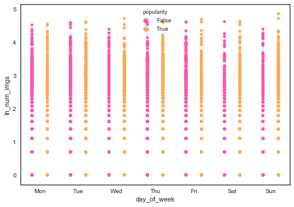

```python
sb.stripplot(x='day_of_week',y='ln_num_imgs',data=dataset,hue='popularity', split=True,palette="spring");
plt.show()
```

Above plot suggest that images are popular more during weekend compared to week days, which correlates well with lifestyle getting more activity over weekend than weekdays and the fact that lifestyle popularity increases with more images.

#### Moving on to Key words ...

- How important is it to have buzz words to influence people to share?

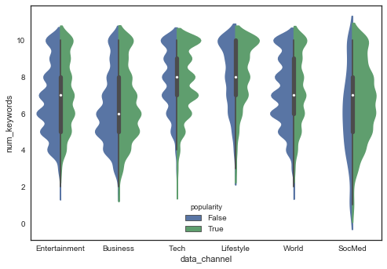

```python
sb.violinplot(x='data_channel',y='num_keywords',data=dataset, hue='popularity', split=True,scale='count');
plt.show()
```

obviously important, very clearly dependent on industry. Social media is full of buzz words,higher the key words very influencial on people. World channel reflects to show more key words no likely popular. Overall, key words is a very good indicator for popularity, data channel and key words combined is a good predictor variable.

#### Next, how long is the title?

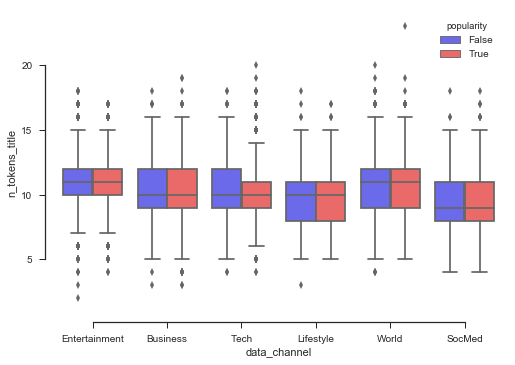

```python
sb.set(style="ticks")
sb.boxplot(x = 'data_channel', y = 'n_tokens_title',data = dataset, hue = 'popularity', palette="seismic" )
sb.despine(offset=10, trim=True)
plt.show()
```

#### New Features

New features have been added to data analysis.

1. data_Channel:  
   • Business  
   • Entertainment  
   • LifeStyle  
   • Social Media  
   • Technology  
   • World

above variables are derived using the corresponding data_channel indicators.

1. day_of_week:  
   • Mon  
   • Tue  
   • Wed  
   • Thu  
   • Fri  
   • Sat  
   • Sun

above variables are derived using weekday_is_monday thru weekday_is_sunday in the original dataset.

# Exceptional work

For exceptional work a logistic regression is done to predict if a url is popular based on the threshold of 1400 shares.

To prepare the dataset for the regression some object and date type variables are removed.

```python
df2 = df1.drop(['publish_date', 'title', 'data_channel', 'day_of_week', 'year', 'month', 'day','url'], axis = 1)
```

## Training and Testing Split

For training and testing purposes, we use 80% of the observations for training and 20% for testing. This process is repeated three times and use the hold out cross validation method built into scikit-learn.

```python
from sklearn.model_selection import ShuffleSplit

if 'popularity' in df2:
    y = df2['popularity'].values
    del df2['popularity']
    X = df2.values

num_cv_iterations = 3
num_instances = len(y)
cv_object = ShuffleSplit(n_splits = num_cv_iterations,
                        test_size = 0.2)

print(cv_object)
```

```
ShuffleSplit(n_splits=3, random_state=None, test_size=0.2, train_size=None)
```

The next bit of code creates the logistic regression model and for each iteration it fit the model to the train and test splits.

The output shows the accuracy and confusion matrix for each iteration.

```python
from sklearn.linear_model import LogisticRegression
from sklearn.metrics import accuracy_score as acc
from sklearn.metrics import confusion_matrix as conf

model = LogisticRegression()

for iter_num, (train_indices, test_indices) in enumerate(cv_object.split(X,y)):
    X_train = X[train_indices]
    y_train = y[train_indices]

    X_test = X[test_indices]
    y_test = y[test_indices]

    model.fit(X_train, y_train)  # train object
    y_hat = model.predict(X_test) # get test set precitions
    print("====Iteration",iter_num," ====")
    print("accuracy", acc(y_test, y_hat) )
    print("confusion matrix\n", conf(y_test, y_hat))
    iter_num+=1
```

```
====Iteration 0  ====
accuracy 0.958758986001
confusion matrix
 [[3856  162]
 [ 165 3746]]
====Iteration 1  ====
accuracy 0.950561230924
confusion matrix
 [[3821  180]
 [ 212 3716]]
====Iteration 2  ====
accuracy 0.919283642326
confusion matrix
 [[3835  252]
 [ 388 3454]]
```

It would also be useful to know how each variable ended up weighted in the regression model. The next bit of code does just that, outputting a list of each variable and weight.

```python
from sklearn.preprocessing import StandardScaler

scl_obj = StandardScaler()
scl_obj.fit(X_train)

X_train_scaled = scl_obj.transform(X_train)
X_test_scaled = scl_obj.transform(X_test)

lr_clf = LogisticRegression(penalty='l2', C=0.05)
lr_clf.fit(X_train_scaled, y_train)

y_het = lr_clf.predict(X_test_scaled)

zip_vars = zip(lr_clf.coef_.T,df2.columns) # combine attributes
zip_vars = sorted(zip_vars)
for coef, name in zip_vars:
    print(name, 'has weight of', coef[0]) # now print them out
```

```
kw_max_avg has weight of -0.211602145304
ln_n_tokens_content has weight of -0.169770500062
kw_avg_min has weight of -0.0995560160655
kw_max_max has weight of -0.0943352955119
num_self_hrefs has weight of -0.0889564351374
LDA_03 has weight of -0.0784016446035
num_imgs has weight of -0.0733957320958
n_unique_tokens has weight of -0.0722403968804
data_channel_is_entertainment has weight of -0.0710219217755
num_videos has weight of -0.0684907989768
LDA_01 has weight of -0.0638523266987
LDA_02 has weight of -0.0612880772925
n_non_stop_unique_tokens has weight of -0.0483294548693
data_channel_is_bus has weight of -0.048311190887
kw_avg_max has weight of -0.0478638846284
global_rate_positive_words has weight of -0.0395044089964
self_reference_avg_sharess has weight of -0.039474721091
weekday_is_wednesday has weight of -0.0382052950594
weekday_is_tuesday has weight of -0.037528594574
data_channel_is_lifestyle has weight of -0.0330206581832
data_channel_is_world has weight of -0.0292081473758
min_positive_polarity has weight of -0.0289536949829
avg_positive_polarity has weight of -0.0285292621606
abs_title_sentiment_polarity has weight of -0.0266033038344
weekday_is_thursday has weight of -0.0189664746271
n_tokens_title has weight of -0.0136927448734
kw_min_avg has weight of -0.0122644617156
timedelta has weight of -0.0117987822088
max_negative_polarity has weight of -0.00893943292789
min_negative_polarity has weight of -0.0087939520806
kw_min_max has weight of -0.00780044950115
weekday_is_monday has weight of -0.00459019505538
global_sentiment_polarity has weight of 0.0101088978643
rate_negative_words has weight of 0.0108440555573
average_token_length has weight of 0.0161621927864
max_positive_polarity has weight of 0.0178860529086
num_hrefs has weight of 0.0259255589007
weekday_is_friday has weight of 0.0265164029266
avg_negative_polarity has weight of 0.0268078931138
ln_kw_avg_avg has weight of 0.0269580803699
```

[output cut: 11 more lines]

```
kw_min_min has weight of 0.0577216760478
ln_self_reference_avg_sharess has weight of 0.0583583569047
n_non_stop_words has weight of 0.0679588151157
rate_positive_words has weight of 0.0792480170199
n_tokens_content has weight of 0.083432590252
weekday_is_saturday has weight of 0.0864405196241
is_weekend has weight of 0.0866748399649
ln_num_videos has weight of 0.0967989725011
ln_num_imgs has weight of 0.102012592162
data_channel_is_tech has weight of 0.105168422386
kw_max_min has weight of 0.106340736736
data_channel_is_socmed has weight of 0.125797341375
LDA_00 has weight of 0.144502947008
kw_avg_avg has weight of 0.3350871109
shares has weight of 15.1798887167
```

The weights listed above are useful but a visualization would make digestion of the information easier. The bar chart below shows the weighting of each variable in the regression. The absolute value or magnitude are what is important here.

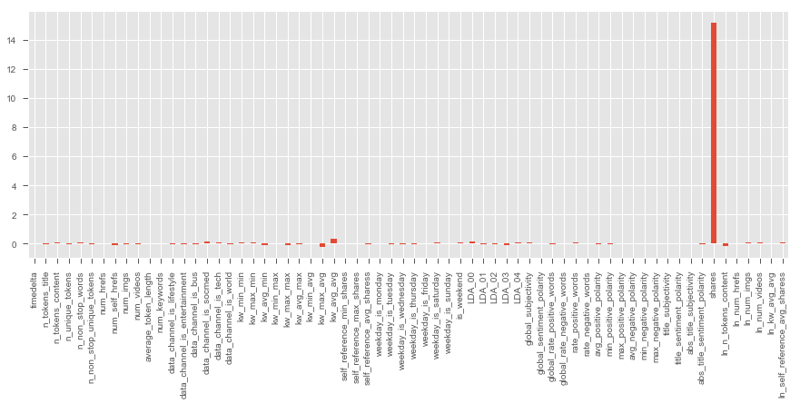

```python
from matplotlib import pyplot as plt
from pylab import rcParams
%matplotlib inline
rcParams['figure.figsize'] = 15, 5
plt.style.use('ggplot')

weights = pd.Series(lr_clf.coef_[0], index = df2.columns)
weights.plot(kind = 'bar')
plt.show()
```

# Dimensionality Reduction

```python
from pandas.tools.plotting import scatter_matrix
from sklearn.decomposition import PCA
from sklearn.discriminant_analysis import LinearDiscriminantAnalysis as LDA
```

```python
pca = PCA(n_components=5)
X_pca = pca.fit(X).transform(X)


print('pca:', pca.components_)
```

[output not shown]

[output cut: 30 more lines]

[output not shown]